# SEV_PlantBiomassRegressions_RoundOne

AJ

2017-10-26 09:54:13

## Background

Several long-term studies at the Sevilleta LTER measure net primary production (NPP) across ecosystems and treatments. Net primary production is a fundamental ecological variable that quantifies rates of carbon consumption and fixation. Estimates of NPP are important in understanding energy flow at a community level as well as spatial and temporal responses to a range of ecological processes. Above-ground net primary production (ANPP) is the change in plant biomass, including loss to death and decomposition, over a given period of time. To measure this change, vegetation variables, including species composition and the cover and height of individuals, are sampled up to three times yearly (winter, spring, and fall) at permanent plots within a study site. Sevilleta LTER dataset 157 includes cover, height, and dry biomass measurements obtained through destructive harvesting. These species are always harvested from habitat comparable to the plots in which they were recorded.

#### Required input files

The following R code requires three source files:  
- Sev dataset 157, which includes volume (cover x height) and weight data from destructively harvested individuals. This is used to create regressions which can be used to estimate seasonal biomass for plant species across the Sevilleta.  
- All available per-quad observations of plant volume and height from across the Sevilleta to characterize the range of plant sizes to which we are applying biomass regressions. (file from email sent from J Rudgers 12 Sept 2017)  
- A file with species names tied to additional taxonomic and life history trait info (Alesia’s personal species list used here)

### Products

This script itself is a product. The code should be transparent and easily reproducible.

This script, when knit, creates a PDF report for every species in the Sev 157 or “all quad” data files. Demographic data, number of observations, and descriptions of linear models will be listed for each species, along with figures which visually describe model interactions. Predictor variables include:  
-individual plant volume (height*cover) -site at which plant occurs -season during which plant was observed -treatment (burned in the past 5 years or “unburned”) -year during which destructive harvest sample was collected

A .csv file is created that includes linear model slopes and p-values for each pairwise comparison of the above the terms.

A list of high-priority species to destructively harvest will also be created. This list will include a reason for suggested harvest and size classes for which we desire samples.

### Step 1: Preparing the data

SEV dataset 157 (version 20161218) is used here.

The data look like this:

|  | Year | Season | Date | Site | Treatment | kartez | Cover | Height | Live_Weight | Volume | SiteCluster |
| --- | --- | --- | --- | --- | --- | --- | --- | --- | --- | --- | --- |
| 10028 | 2003 | 3 | 9/30/2003 | P | C | ACNE | 0.01 | 2 | 0.01 | 0.02 | PJ |
| 10029 | 2003 | 3 | 9/30/2003 | P | C | ACNE | 0.01 | 2 | 0.01 | 0.02 | PJ |
| 10030 | 2003 | 3 | 9/30/2003 | P | C | ACNE | 0.01 | 3 | 0.01 | 0.03 | PJ |
| 10031 | 2003 | 3 | 9/30/2003 | P | C | ACNE | 0.05 | 4 | 0.01 | 0.20 | PJ |
| 10032 | 2003 | 3 | 9/30/2003 | P | C | ACNE | 0.05 | 4 | 0.01 | 0.20 | PJ |
| 10033 | 2003 | 3 | 9/30/2003 | P | C | ACNE | 0.05 | 4 | 0.01 | 0.20 | PJ |

```r
# read in all Sev quad data
allquadNPP <- read.csv("/Users/alesia/Documents/Project_SevPublicPlantRCode/NPP_quad_met2016.csv", strip.white = T)

# reshape data.frame to long format
colnames(allquadNPP)
```

```
##   [1] "X"            "year"         "site"         "treat"
##   [5] "season"       "web"          "plot"         "subplot"
##   [9] "quad_ID"      "quad"         "a_f"          "a_g"
##  [13] "p_f"          "p_g"          "p_s"          "p_t"
##  [17] "C3"           "C4"           "CAM"          "NA."
##  [21] "ACNE"         "AGHE5"        "ALIN"         "ALMA4"
##  [25] "AMAL"         "AMARA"        "AMBL"         "AMPA"
##  [29] "APRAH"        "ARAD"         "ARFEF"        "ARIST"
##  [33] "ARLUL2"       "ASFE2"        "ASFL2"        "ASMIM"
##  [37] "ASNU4"        "ASTRA"        "ATCA2"        "BAABA"
##  [41] "BADI"         "BAMU"         "BAPT"         "BELY"
##  [45] "BOBA2"        "BOCU"         "BOER4"        "BOGR2"
##  [49] "BOHI2"        "BOSP"         "BRBR2"        "BRCA3"
##  [53] "BREUC2"       "CEMOP"        "CHAL11"       "CHCHC3"
##  [57] "CHCO"         "CHCO2"        "CHER2"        "CHFE3"
```

[output cut: 54 more lines]

```r
allquadNPP <- gather(allquadNPP, key = kartez, value = old.NPP, 21:242)
allquadNPP <- allquadNPP[allquadNPP$old.NPP > 0,]

# reduce to columns of interest
allquadNPP <- allquadNPP[,c("year", "site", "treat", "season", "web", "plot", "subplot", "quad_ID", "quad", "biome", "annual", "GDD", "SPEI12", "kartez", "old.NPP")]

#ggplot(allquadNPP[allquadNPP$kartez == unique(allquadNPP$kartez)[25] & allquadNPP$season == 3,], aes(x=log10(old.NPP), y=..count.., group=biome, fill=biome)) + geom_histogram()
```

```r
# Read in species' taxonomy data
taxo <- read.csv("/Users/alesia/Documents/Project_SevPublicPlantRCode/SevilletaSpeciesList_AJH.csv", strip.white = T)

# Revalue a_p and g_f columns
taxo$a_p <- revalue(taxo$a_p, c(
  "a" = "annual",
  "p" = "perennial",
  "a/p" = "annual/perennial"))
taxo$g_f <- revalue(taxo$g_f, c(
  "f" = "forb",
  "t" = "tree",
  "g" = "grass",
  "s" = "shrub"))

# Merge taxonomy file onto other two datasets
dest.harv.extend <- merge(dest.harv.extend, taxo[,c("kartez", "family", "genus", "species", "path", "a_p", "g_f")], by="kartez", all.x=T)
allquadNPP <- merge(allquadNPP, taxo[,c("kartez", "family", "genus", "species", "path", "a_p", "g_f")], by="kartez", all.x=T)

# Find species in the destructive harvest file that are not in the taxo file
dest.sp.err <- unique(dest.harv.extend$kartez[!dest.harv.extend$kartez %in% taxo$kartez])

# Exclude unknown species
dest.harv.extend <- dest.harv.extend[!dest.harv.extend$kartez %in% c("FORB1", "UKFO10", "UKFO13", "UKFO17", "UKFO18", "UKFO75", "UKFO80", "UKSH5"),]

# Exclude woody species. Need to be treated separately
dest.harv.extend <- dest.harv.extend[!dest.harv.extend$kartez %in% c("LATR2F", "LATR2L", "LATR2T", "LATR2W", "QUTU2B", "YUBAC", "YUBAL"),]

#dest.harv.extend[dest.harv.extend$kartez == "MUPA",]
#allquadNPP[allquadNPP$kartez == "MUPA2",]

# Correct typos
dest.harv.extend$kartez <- revalue(dest.harv.extend$kartez, c(
  "CHLA2" = "CHAL11", #guess based on cover/height/presence in other datasets
  "CHST" = "CHST8", #these don't even have heights
  "DIW12" = "DIWI2",
  "MUPA" = "MUPA2",
  "SPOR" = "SPORO"))

# Update old species names
dest.harv.extend$kartez <- revalue(dest.harv.extend$kartez, c(
  "MOSQ" = "MUSQ3",
  "OPCL" = "GRCL",
  "OPIM" = "CYIMI",
  "STNE2" = "HENE5"))

# I don't know what these species are. exclude for now
dest.harv.extend <- dest.harv.extend[!dest.harv.extend$kartez %in% c("PF3", "POAC6"),]

# Find species in the all quad NPP file that are not in the taxo file
allquad.sp.err <- unique(allquadNPP$kartez[!allquadNPP$kartez %in% taxo$kartez])

#unique(allquadNPP[allquadNPP$kartez == "STEM" &
#                         allquadNPP$site == "C",])

# I don't know what these species are. exclude for now
allquadNPP <- allquadNPP[!allquadNPP$kartez %in% c("STEM"),]
```

```r
# Species for which we have quad data but NO destructive measurements
missing.dest <- merge(unique(allquadNPP[!allquadNPP$kartez %in% dest.harv.extend$kartez, c("year", "site", "kartez")]), taxo[,c("kartez", "family", "genus", "species", "path", "a_p", "g_f")], by="kartez", all.x=T)

cat("  \n\n Species for which we have quad data but NO destructive measurements: \n")
```

```
##
##
##  Species for which we have quad data but NO destructive measurements:
```

```r
kable(unique(missing.dest[,c("kartez", "family", "genus", "species")]), format="pandoc")
```

|  | kartez | family | genus | species |
| --- | --- | --- | --- | --- |
| 1 | AMAL | Amaranthaceae | Amaranthus | albus |
| 5 | AMBL | Amaranthaceae | Amaranthus | blitoides |
| 6 | ARIST | Poaceae | Aristida |  |
| 138 | ASFE2 | Fabaceae | Astragalus | missouriensis |
| 157 | ASFL2 | Fabaceae | Astragalus | flexuosus |
| 161 | ASTRA | Fabaceae | Astragalus |  |
| 202 | CHCHC3 | Euphorbiaceae | Chamaesyce | chaetocalyx |
| 206 | COAR4 | Convolvulaceae | Convolvulus | arvensis |
| 207 | COAU2 | Fumariaceae | Corydalis | aurea |
| 208 | COEQ | Convolvulaceae | Convolvulus | equitans |
| 219 | CRCI3 | Boraginaceae | Cryptantha | cinerea |
| 227 | DALEA | Fabaceae | Dalea |  |
| 228 | ECFEF3 | Cactaceae | Echinocereus | fendleri |
| 248 | ERAB2 | Polygonaceae | Eriogonum | abertianum |
| 255 | ERTE13 | Geraniaceae | Erodium | texanum |
| 262 | FUCR | Asclepiadaceae | Funastrum | crispum |
| 264 | GAPU | Asteraceae | Gaillardia | pulchella |
| 265 | GLBI2 | Verbenaceae | Glandularia | bipinnatifida |
| 297 | GUSP | Asteraceae | Gutierrezia | sphaerocephala |
| 302 | HENA | Lamiaceae | Hedeoma | nana |
| 309 | HOGL2 | Fabaceae | Hoffmannseggia | glauca |
| 312 | HORU | Rubiaceae | Houstonia | rubra |
| 313 | HYVE | Violaceae | Hybanthus | verticillatus |
| 315 | IPCO2 | Convolvulaceae | Ipomoea | costellata |
| 334 | IPLO2 | Polemoniaceae | Ipomopsis | longiflora |
| 337 | KAHI | Zygophyllaceae | Kallstroemia | hirsutissima |
| 341 | LEDE | Brassicaceae | Lepidium | densiflorum |
| 351 | LEPI3 | Brassicaceae | Lesquerella | pinetorum |
| 363 | MACA2 | Asteraceae | Machaeranthera | canescens |
| 365 | MATA2 | Asteraceae | Machaeranthera | tanacetifolia |
| 368 | MESC | Oleaceae | Menodora | scabra |
| 386 | MOCE | Molluginaceae | Mollugo | cerviana |
| 396 | MUFR | Poaceae | Muhlenbergia | fragilis |
| 397 | OECA10 | Onagraceae | Oenothera | caespitosa |
| 483 | OPPH | Cactaceae | Opuntia | phaeacantha |
| 537 | OPPOP | Cactaceae | Opuntia | polyacantha |
| 540 | OPUNT | Cactaceae | Opuntia |  |
| 545 | PAHI5 | Poaceae | Panicum | hirticaule |
| 546 | PELO3 | Brassicaceae | Pennellia | longifolia |
| 547 | PHACE | Hydrophyllaceae | Phacelia |  |
| 555 | PHCR | Hydrophyllaceae | Phacelia | crenulata |
| 577 | PHHE4 | Solanaceae | Physalis | hederifolia |
| 580 | PHLO15 | Portulacaceae | Phemeranthus | longipes |
| 582 | PHLOL3 | Solanaceae | Physalis | longifolia |
| 583 | PHYSA | Solanaceae | Physalis |  |
| 584 | QUERC | Fagaceae | Quercus |  |
| 586 | QUPA | Fagaceae | Quercus | palaeolithicola |
| 591 | RANE | Asteraceae | Rafinesquia | neomexicana |
| 592 | SCLA6 | Asteraceae | Scorzonera | laciniata |
| 598 | SCPA10 | Cactaceae | Sclerocactus | papyracanthus |
| 615 | SIAL2 | Brassicaceae | Sisymbrium | altissimum |
| 617 | SPPO6 | Malvaceae | Sphaeralcea | polychroma |
| 763 | TEAR4 | Asteraceae | Tetraneuris | argentea |
| 765 | THME | Asteraceae | Thelesperma | megapotamicum |

```r
# Species for which we have destructive measurements but no quad data
unused.reg <- merge(unique(dest.harv.extend[!dest.harv.extend$kartez %in% allquadNPP$kartez, c("Year", "Site", "kartez")]), taxo[,c("kartez", "family", "genus", "species", "path", "a_p", "g_f")], by="kartez", all.x=T)

cat("  \n\n Species for which we have destructive measurements but no quad data: \n")
```

```
##
##
##  Species for which we have destructive measurements but no quad data:
```

```r
kable(unique(unused.reg[,c("kartez", "family", "genus", "species")]), format="pandoc")
```

|  | kartez | family | genus | species |
| --- | --- | --- | --- | --- |
| 1 | ARDI5 | Poaceae | Aristida | divaricata |
| 13 | ARPUP6 | Poaceae | Aristida | purpurea |
| 34 | ASLA4 | Asclepiadaceae | Asclepias | latifolia |
| 35 | CAHA14 | Onagraceae | Calylophus | hartwegii |
| 36 | CHGL13 | Euphorbiaceae | Chamaesyce | glyptosperma |
| 42 | CYMO | Apiaceae | Cymopterus | montanus |
| 43 | DAJA | Fabaceae | Dalea | jamesii |
| 45 | FEAR2 | Poaceae | Festuca | arizonica |
| 48 | GLWR | Verbenaceae | Glandularia | bipinnatifida |
| 55 | HYRIF | Asteraceae | Hymenoxys | richardsonii |
| 58 | LEDED | Brassicaceae | Lepidium | densiflorum |
| 59 | LEOV | Brassicaceae | Lesquerella | ovalifolia |
| 64 | MUMO | Poaceae | Muhlenbergia | montana |
| 67 | MURE | Poaceae | Muhlenbergia | repens |
| 69 | OECAC2 | Onagraceae | Oenothera | caespitosa |
| 73 | OPPHP | Cactaceae | Opuntia | phaeacantha |
| 82 | POAL4 | Polygalaceae | Polygala | alba |
| 83 | POBI | Poaceae | Poa | bigelovii |
| 84 | QUTU2 | Fagaceae | Quercus | turbinella |
| 88 | SPCO4 | Poaceae | Sporobolus | contractus |
| 96 | SPCR | Poaceae | Sporobolus | cryptandrus |
| 100 | SPFL2 | Poaceae | Sporobolus | flexuosus |
| 103 | SPIN2 | Malvaceae | Sphaeralcea | incana |

```r
# Create full matrix for model output
model.coefs.all <- data.frame(
  kartez = as.factor(NA),
  Year = as.factor(NA),
  Site = as.factor(NA),
  Season = as.factor(NA),
  Treatment = as.factor(NA),
  Beta.Volume = NA,
  SE = NA,
  p.value = NA,
  AdjR = NA)
```

# Species Overviews

### Species: ACNE

*Acalypha neomexicana* (Euphorbiaceae) - annual C3 forb  
*Destructive Harvest Data*:  
Number of observations: Total - 34 , Winter - 0 , Spring - 0 , Fall - 34  
Sites sampled: P - 34  
Years collected: 2003 - 9, 2006 - 13, 2008 - 12  
Burn effects considered: No  
*Size range*: Cover: 0.01 - 3 , Height: 2 - 37 , Volume: 0.02 - 102 Weight: 0.01 - 1.09

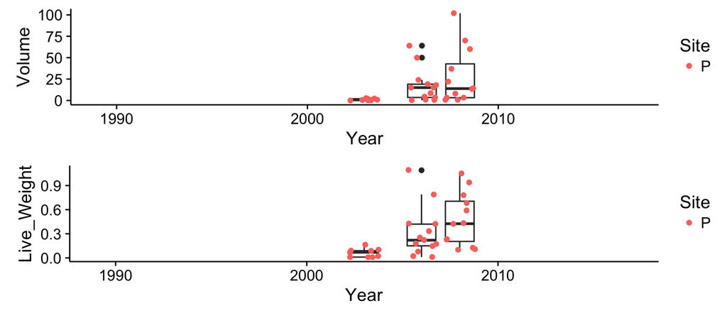

Model: Live_Weight ~ 0 + Volume + Volume*Year

- Volume main effect: 0.251371
- Volume:Year interaction: 0.001502397
- Volume:Site interaction: NA
- Volume:Season interaction: NA
- Volume:Treatment interaction: NA

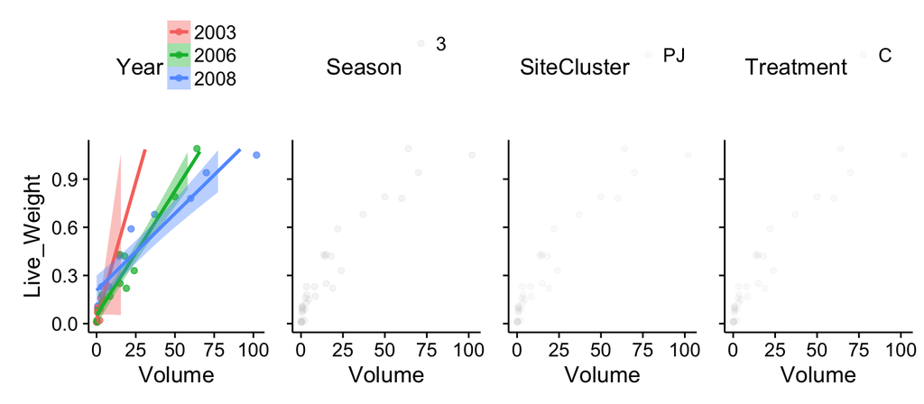

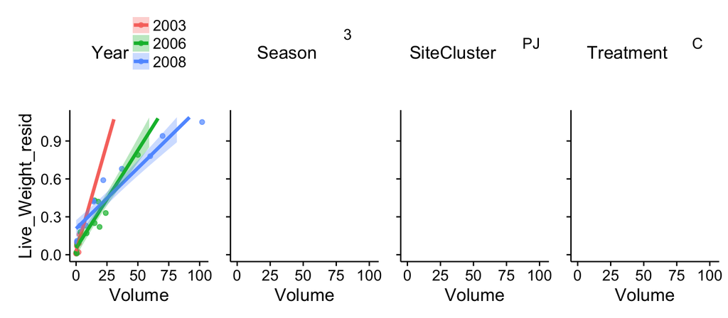

### Species: AGHE5

*Ageratina herbacea* (Asteraceae) - perennial C3 forb  
*Destructive Harvest Data*:  
Number of observations: Total - 12 , Winter - 0 , Spring - 0 , Fall - 12  
Sites sampled: P - 12  
Years collected: 2013 - 12  
Burn effects considered: No  
*Size range*: Cover: 0.1 - 10 , Height: 3 - 60 , Volume: 0.3 - 600 Weight: 0.02 - 24.57

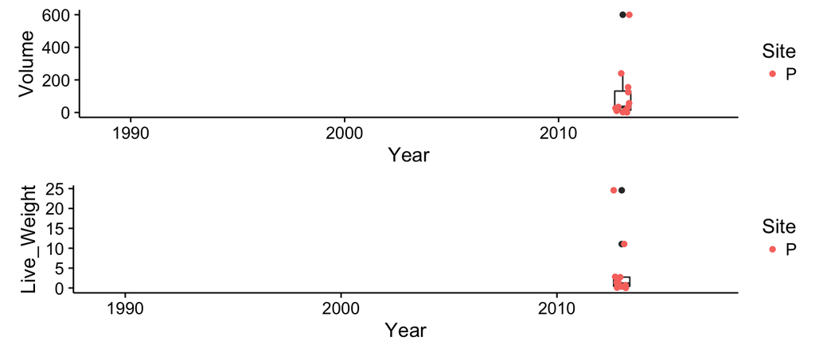

### Species: ALIN

*Allionia incarnata* (Nyctaginaceae) - perennial C4 forb  
*Destructive Harvest Data*:  
Number of observations: Total - 38 , Winter - 0 , Spring - 5 , Fall - 33  
Sites sampled: G - 11, L - 27  
Years collected: 1999 - 6, 2000 - 5, 2004 - 14, 2006 - 13  
Burn effects considered: No  
*Size range*: Cover: 0.01 - 35 , Height: 1 - 22 , Volume: 0.01 - 560 Weight: 0.01 - 37.12

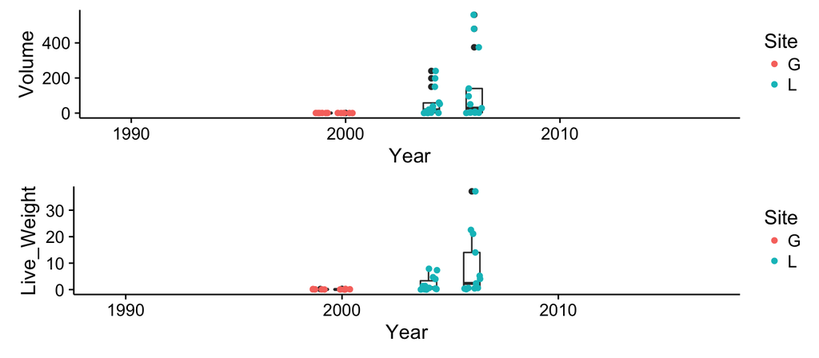

Model: Live_Weight ~ 0 + Volume + Volume*Year

- Volume main effect: 0.9731468
- Volume:Year interaction: 0.009912358
- Volume:Site interaction: NA
- Volume:Season interaction: NA
- Volume:Treatment interaction: NA

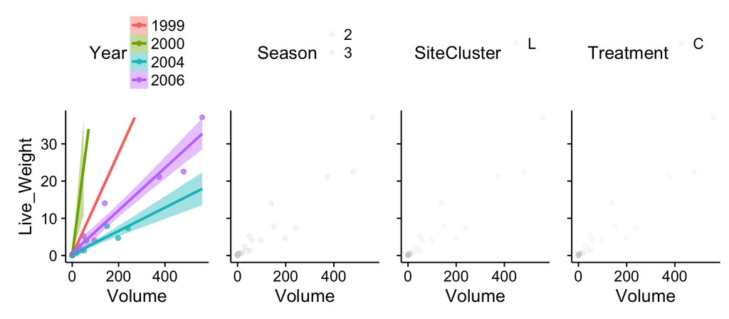

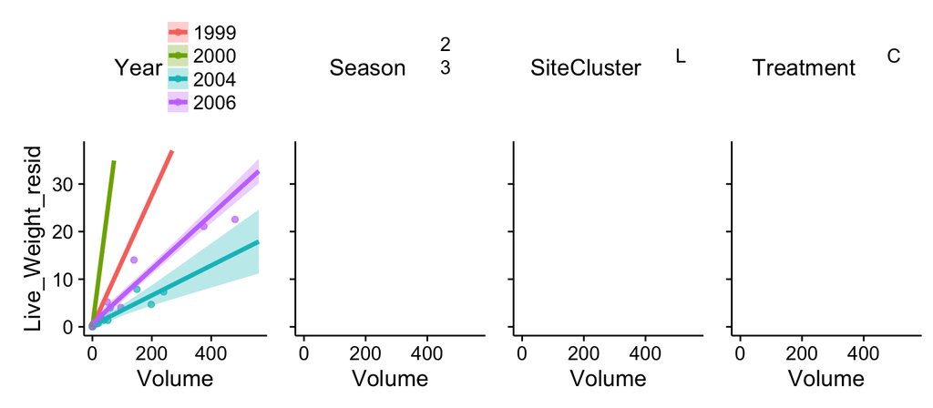

### Species: ALMA4

*Allium macropetalum* (Liliaceae) - perennial C3 forb  
*Destructive Harvest Data*:  
Number of observations: Total - 12 , Winter - 0 , Spring - 0 , Fall - 12  
Sites sampled: B - 12  
Years collected: 2003 - 12  
Burn effects considered: No  
*Size range*: Cover: 0.05 - 0.5 , Height: 3 - 18 , Volume: 0.15 - 9 Weight: 0.01 - 0.23

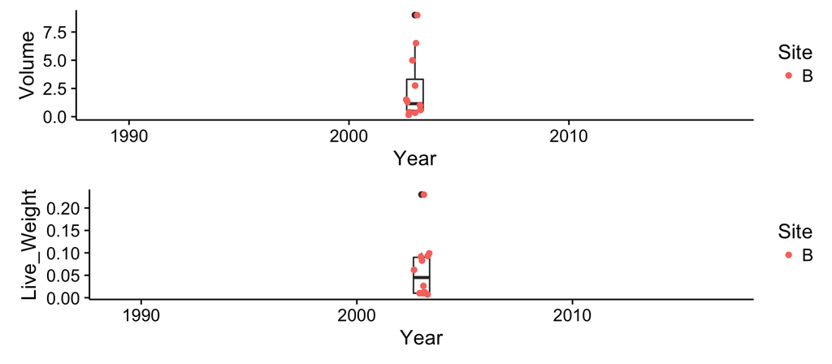

### Species: AMPA

*Amaranthus palmeri* (Amaranthaceae) - annual C4 forb  
*Destructive Harvest Data*:  
Number of observations: Total - 28 , Winter - 0 , Spring - 0 , Fall - 28  
Sites sampled: B - 13, P - 15  
Years collected: 2002 - 13, 2003 - 15  
Burn effects considered: No  
*Size range*: Cover: 0.01 - 1 , Height: 1 - 31 , Volume: 0.01 - 31 Weight: 0.01 - 1.08

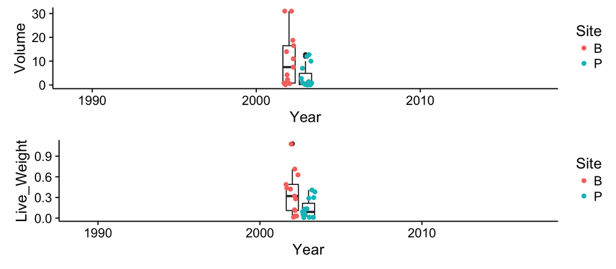

Model: Live_Weight ~ 0 + Volume

- Volume main effect: 1.949404e-18
- Volume:Year interaction: NA
- Volume:Site interaction: NA
- Volume:Season interaction: NA
- Volume:Treatment interaction: NA

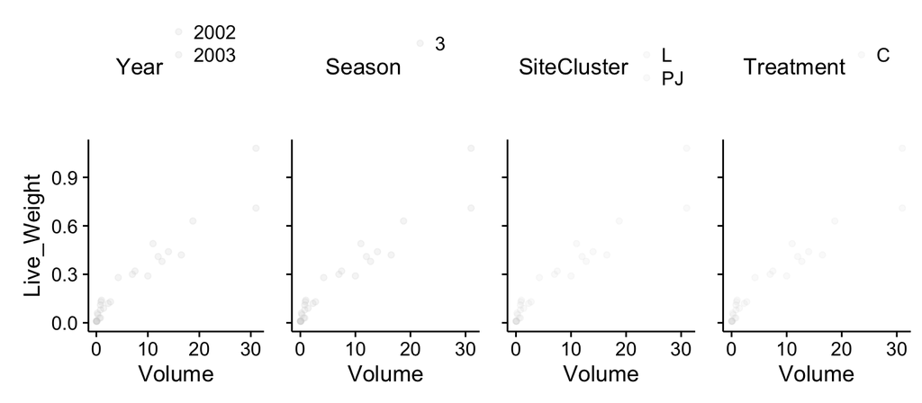

[figure not shown]